# Story Part 1

’Twas the day after Christmas, and all through the drifts. The people were playing, enjoying their gifts. Except for your Special Someone! 😟

It’s the day after Christmas and you realize you’ve forgotten to give your special someone that quilt you were planning on making them. In fact, you haven’t even started. You find a quilt pattern online which thankfully comes pre-gridded in csv format (your puzzle input) and get to work. The pattern you found has eight colors

```
red
orange
yellow
green
blue
indigo
violet
white
```

which are condensed to individual letters: `r o y g b i v w`.

The pattern also calls for a fringe around the border of the quilt. This is marked with an `x`.

An example pattern may look like this

```
x   x   x   x   x   x   x   x   x   x
x   b   v   o   o   r   r   b   b   x
x   o   w   o   o   r   r   b   b   x
x   v   v   g   y   y   b   y   y   x
x   v   v   o   y   y   g   y   y   x
x   o   o   w   g   i   y   r   w   x
x   o   o   i   b   r   r   b   b   x
x   g   w   g   i   r   r   b   b   x
x   i   i   v   v   i   i   w   g   x
x   i   i   v   v   i   i   r   v   x
x   v   g   o   y   r   g   y   g   x
x   x   x   x   x   x   x   x   x   x
```

and in color

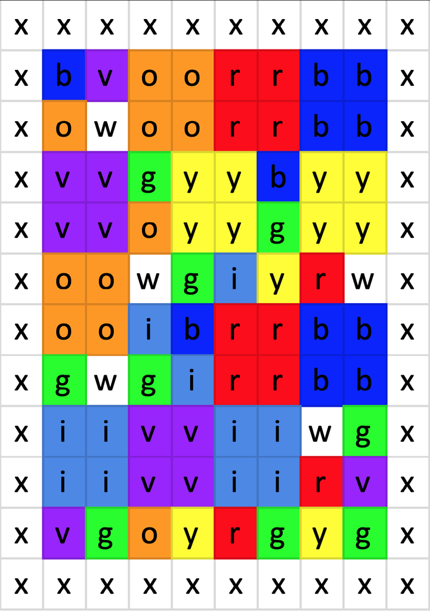

You’re trying to figure out if it is more economical to buy pre-cut patches of fabric or fabric by the yard. The base of the quilt will be white so you don’t need to count those. You want to know `how many patches you will need for the quilt`.

Using the example input, the result would is as follows.

| Color | Number of Squares |
| --- | --- |
| red | 5 |
| orange | 5 |
| yellow | 5 |
| green | 9 |
| blue | 5 |
| indigo | 5 |
| violet | 5 |

To get the answer, you add all the square counts together (but not white) , which is `5 + 5 + 5 + 9 + 5 + 5 + 5 = 39`. Thus, the answer is `39`.

Of course, your pattern is much larger. `How many squares of fabric do you need to make the quilt?`